# Title: Determining RNA Trajectory Analysis

## Genome Annotation

```r
# extract gene annotations from EnsDb
annotations <- GetGRangesFromEnsDb(ensdb = EnsDb.Hsapiens.v75)
```

[output not shown]

[output cut: 16 more lines]

[output not shown]

```r
# change to UCSC style since the data was mapped to hg19
seqlevelsStyle(annotations) <- 'UCSC'

# add the gene information to the object
Annotation(bone) <- annotations
```

## Quality Control

### Metrics

```r
bone <- TSSEnrichment(bone)
```

```
## Extracting TSS positions
```

```
## Extracting fragments at TSSs
```

```
##
## Computing TSS enrichment score
```

```r
bone <- NucleosomeSignal(bone)
bone$blacklist_fraction <- FractionCountsInRegion(bone, regions = blacklist_hg19)
```

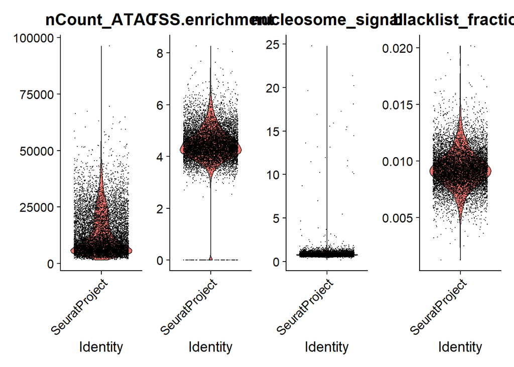

```r
VlnPlot(
  object = bone,
  features = c("nCount_ATAC", "TSS.enrichment", "nucleosome_signal", "blacklist_fraction"),
  pt.size = 0.1,
  ncol = 4
)
```

### Filter dataset

```r
high_nCount <- quantile(bone[["nCount_ATAC"]]$nCount_ATAC , probs = 0.98)
high_ns <- quantile(bone[["nucleosome_signal"]]$nucleosome_signal, probs = 0.98, na.rm = TRUE)
low_ts <- quantile(bone[["TSS.enrichment"]]$TSS.enrichment, probs = 0.02)

bone <- bone[, (bone$nCount_ATAC < high_nCount) &
               (bone$TSS.enrichment > low_ts) &
               (bone$nucleosome_signal < high_ns)]
```

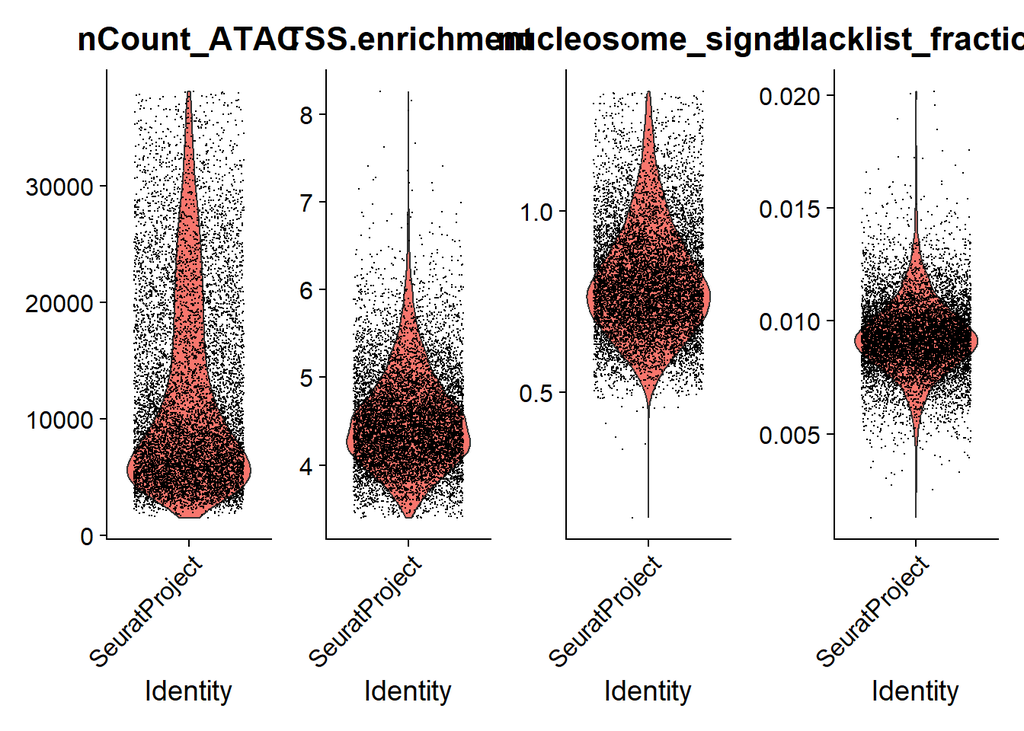

```r
VlnPlot(
  object = bone,
  features = c("nCount_ATAC", "TSS.enrichment", "nucleosome_signal", "blacklist_fraction"),
  pt.size = 0.1,
  ncol = 4
)
```

## Normalization and Linear dimensionality reduction

```r
bone <- FindTopFeatures(bone, min.cells = 10)
bone <- RunTFIDF(bone)
```

```
## Performing TF-IDF normalization
```

```r
bone <- RunSVD(bone, n = 100)
```

```
## Running SVD
```

```
## Scaling cell embeddings
```

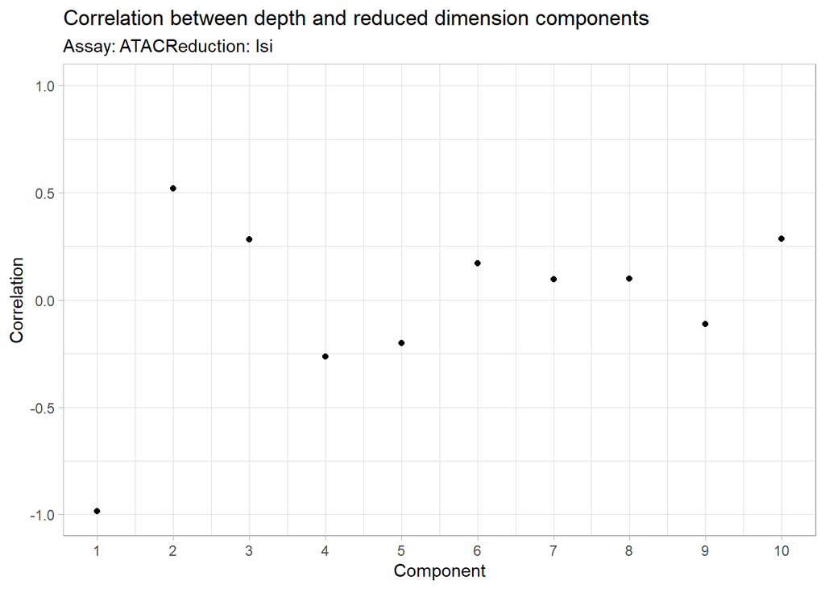

```r
DepthCor(bone)
```

## Clustering and Nonlinear dimensionality reduction

```r
bone <- FindNeighbors(bone, dims = 2:50, reduction = "lsi")
bone <- FindClusters(bone, resolution = 0.8, algorithm = 3)
```

```
## Modularity Optimizer version 1.3.0 by Ludo Waltman and Nees Jan van Eck
##
## Number of nodes: 9360
## Number of edges: 418298
##
## Running smart local moving algorithm...
## Maximum modularity in 10 random starts: 0.8452
## Number of communities: 19
## Elapsed time: 8 seconds
```

```
## 5 singletons identified. 14 final clusters.
```

```r
bone <- RunUMAP(
  bone,
  reduction = "lsi",
  dims = 2:50,
  reduction.name = "UMAP"
)
```

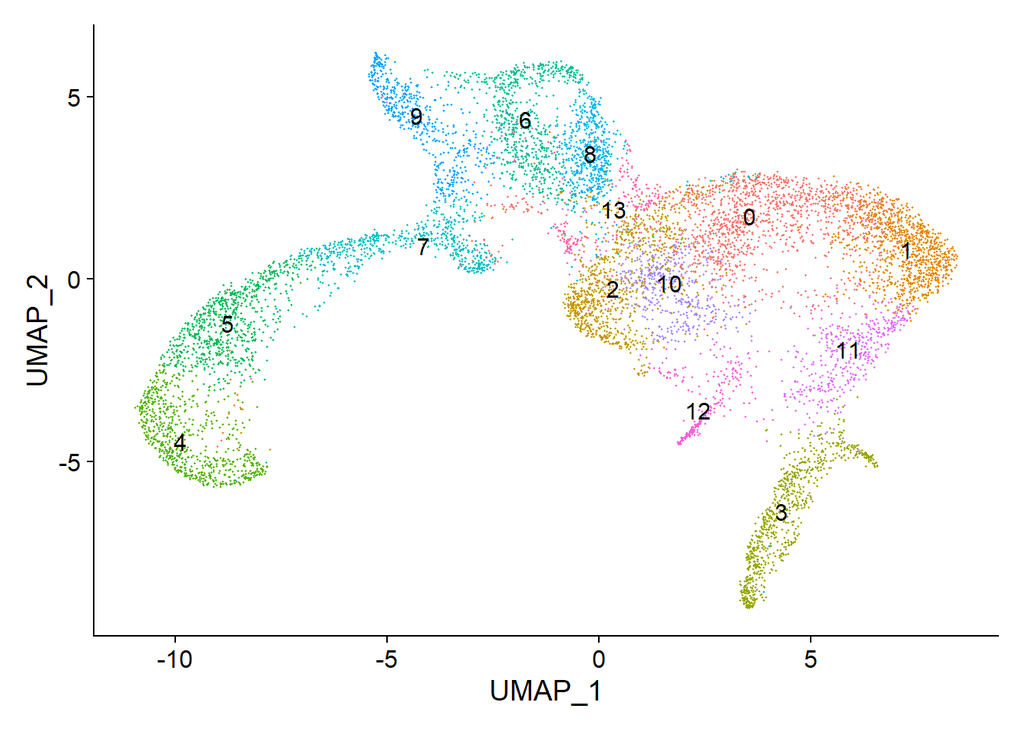

```r
DimPlot(bone, label = TRUE) + NoLegend()
```

Assign each cluster to the most common cell type based on the original annotations from the paper.

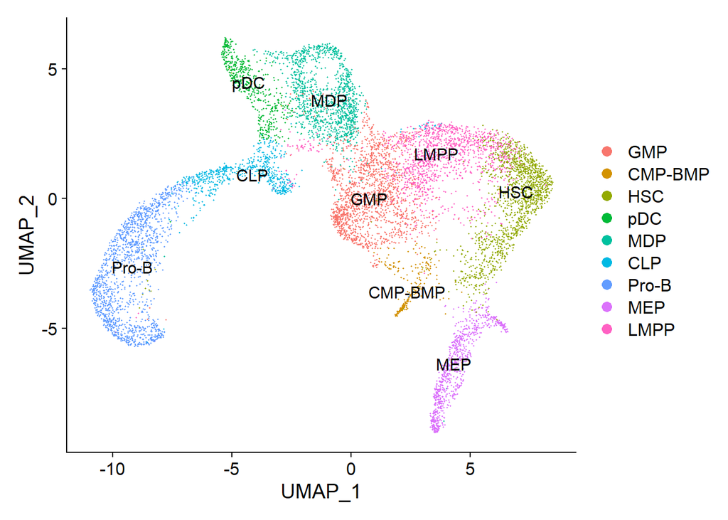

```r
for(i in levels(bone)) {
  cells_to_reid <- WhichCells(bone, idents = i)
  newid <- names(sort(table(bone$celltype[cells_to_reid]),decreasing=TRUE))[1]
  Idents(bone, cells = cells_to_reid) <- newid
}
bone$assigned_celltype <- Idents(bone)

DimPlot(bone, label = TRUE)
```

Next we can subset the different lineages and create a trajectory for each lineage. Another way to build the trajectories is to use the whole dataset and build separate pseudotime trajectories for the different cell partitions found by Monocle 3.

```r
DefaultAssay(bone) <- "ATAC"

erythroid <- bone[,  bone$assigned_celltype %in% c("HSC", "MEP", "CMP-BMP")]
lymphoid <- bone[, bone$assigned_celltype %in% c("HSC", "LMPP", "GMP", "CLP", "Pro-B", "pDC", "MDP", "GMP")]
```

## Building Trajectories with Monocle 3

We can convert the Seurat object to a CellDataSet object using the as.cell_data_set() function from SeuratWrappers and build the trajectories using Monocle 3. We’ll do this separately for erythroid and lymphoid lineages, but you could explore other strategies building a trajectory for all lineages together.

```r
erythroid.cds <- as.cell_data_set(erythroid)
erythroid.cds <- cluster_cells(cds = erythroid.cds, reduction_method = "UMAP")
erythroid.cds <- learn_graph(erythroid.cds, use_partition = TRUE)
lymphoid.cds <- as.cell_data_set(lymphoid)
lymphoid.cds <- cluster_cells(cds = lymphoid.cds, reduction_method = "UMAP")
lymphoid.cds <- learn_graph(lymphoid.cds, use_partition = TRUE)
```

To compute pseudotime estimates for each trajectory we need to decide what the start of each trajectory is. In our case, we know that the hematopoietic stem cells are the progenitors of other cell types in the trajectory, so we can set these cells as the root of the trajectory. Monocle 3 includes an interactive function to select cells as the root nodes in the graph. This function will be launched if calling order_cells() without specifying the root_cells parameter. Here we’ve pre-selected some cells as the root, and saved these to a file for reproducibility. The file can be downloaded [here](https://www.dropbox.com/s/w5jbokcj9u6iq04/hsc_cells.txt)

```
## Cells aren't colored in a way that allows them to be grouped.
```

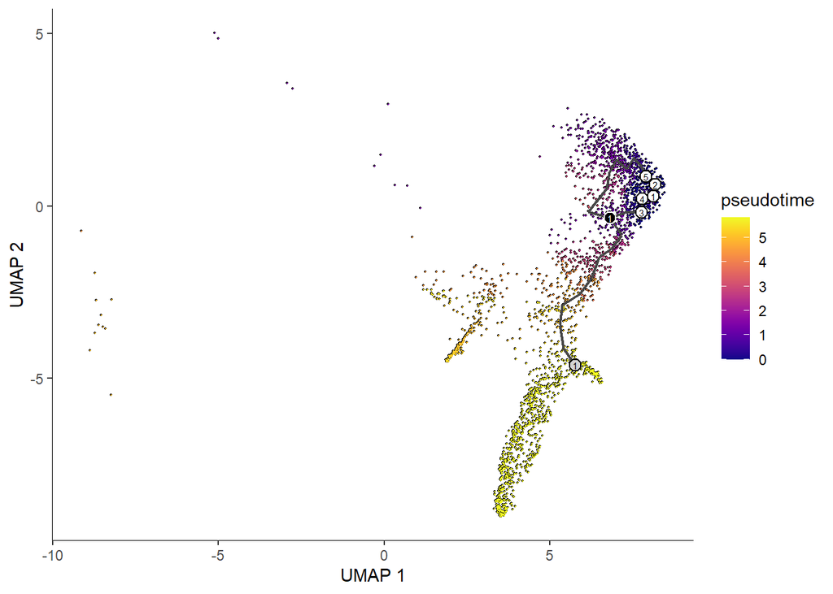

```r
# load the pre-selected HSCs
hsc <- readLines("../../data/traj_analysis/hsc_cells.txt")

# order cells
erythroid.cds <- order_cells(erythroid.cds, reduction_method = "UMAP", root_cells = hsc)
lymphoid.cds <- order_cells(lymphoid.cds, reduction_method = "UMAP", root_cells = hsc)

# plot trajectories colored by pseudotime
plot_cells(
  cds = erythroid.cds,
  color_cells_by = "pseudotime",
  show_trajectory_graph = TRUE
)
```

```
## Cells aren't colored in a way that allows them to be grouped.
```

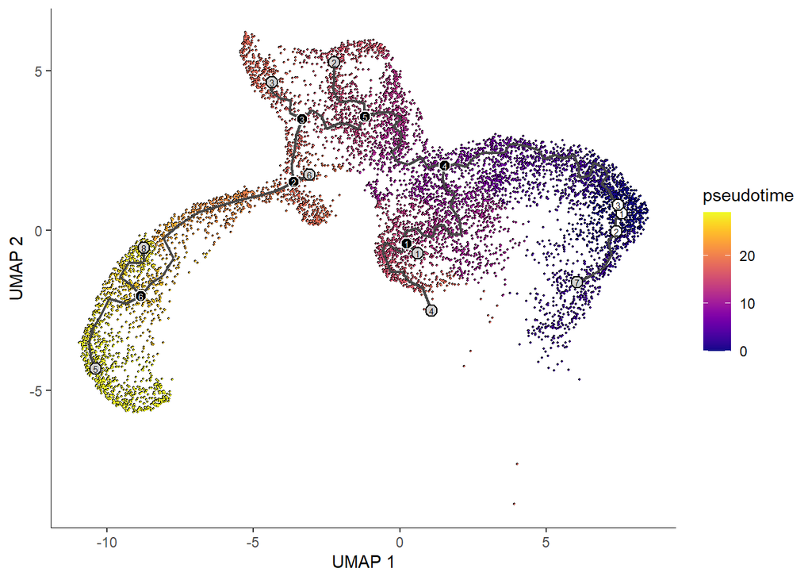

```r
plot_cells(
  cds = lymphoid.cds,
  color_cells_by = "pseudotime",
  show_trajectory_graph = TRUE
)
```

Extract the pseudotime values and add to the Seurat object

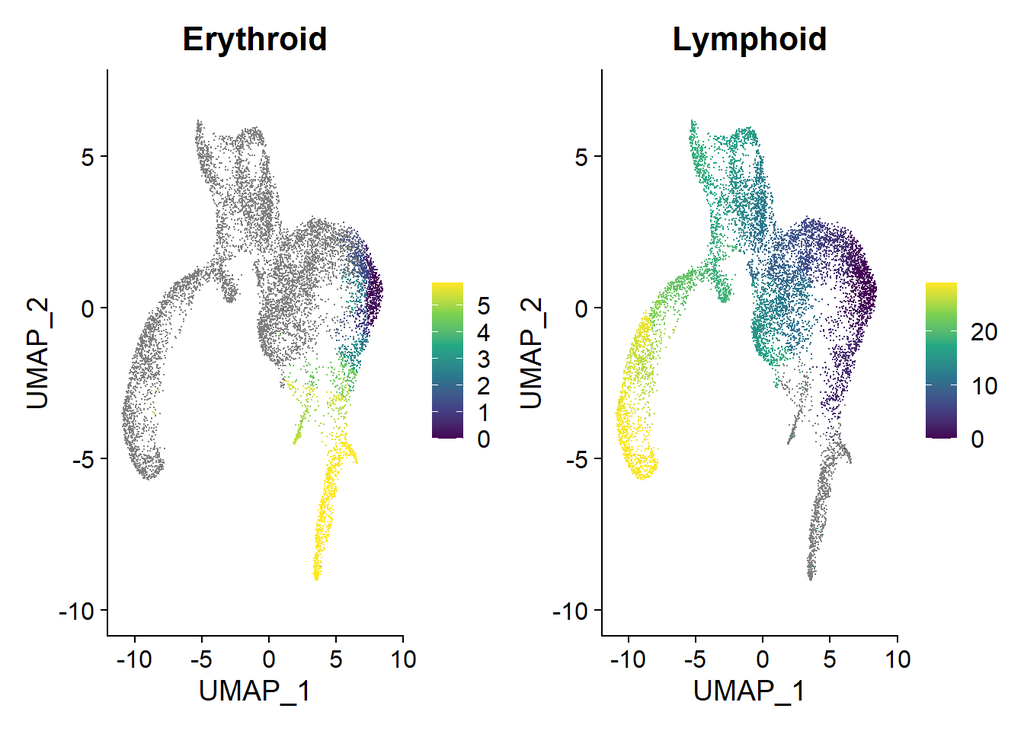

```r
bone <- AddMetaData(
  object = bone,
  metadata = erythroid.cds@principal_graph_aux@listData$UMAP$pseudotime,
  col.name = "Erythroid"
)

bone <- AddMetaData(
  object = bone,
  metadata = lymphoid.cds@principal_graph_aux@listData$UMAP$pseudotime,
  col.name = "Lymphoid"
)

FeaturePlot(bone, c("Erythroid", "Lymphoid"), pt.size = 0.1) & scale_color_viridis_c()
```

## Unload packages

```r
p_unload(pacman, Seurat, Signac, SeuratWrappers, monocle3, ggplot2, Matrix, EnsDb.Hsapiens.v75, Rsamtools)
```

```
## The following packages were not previously loaded:
## Rsamtools
```

```
## The following packages have been unloaded:
## pacman, Seurat, Signac, SeuratWrappers, monocle3, ggplot2, Matrix, EnsDb.Hsapiens.v75
```

```r
rm(list = ls())
```